# RandomForest

Polina Kozyulina, Yulia Kondratenko, Anastasia Gainullina

May 17, 2017

```r
library(dplyr)
library(randomForest)
library(ggplot2)

setwd('/media/polina/305622A3562269B4/bioR/RandomForest/random_forest_hw')
```

## Предподготовка данных

Читаем таблицы и готовим данные. Считаем коэффициенты корелляции для возраста и всех сайтов метилирования, и выбираем 10 наиболее значимых сайтов.

```r
ages <- read.table("ages.tsv", sep="\t", header=1)
head(ages)
```

```
##   Sample Age              Array
## 1    F78  20 Sequenom Massarray
## 2    F79  21 Sequenom Massarray
## 3    F80  22 Sequenom Massarray
## 4    F81  23 Sequenom Massarray
## 5    F82  24 Sequenom Massarray
## 6    F83  25 Sequenom Massarray
```

```r
methylation <- read.table("methylation.tsv", sep="\t", header=1, row.names = 1, na.strings = "NA")
print(methylation[1:5, 1:5])
```

```
##    Primer Chr                   Position  F78  F79
## X1     P1   1                   43425337 0.24 0.09
## X2     P1   1 43425369;43425373;43425375 0.63 0.25
## X3     P1   1                   43425385 0.69 0.44
## X4     P1   1          43425452;43425460 0.88 0.45
## X5     P1   1                   43425479 0.89 0.43
```

```r
# заменяем NA на нули
methylation[is.na(methylation)] <- 0
sum(is.na(methylation))
```

```
## [1] 0
```

```r
# Подготавливаем объединенный датафрейм
methilation_age <- as.data.frame(t(methylation))
head(methilation_age[1:5, 1:5])
```

```
##                X1                         X2       X3                X4
## Primer         P1                         P1       P1                P1
## Chr             1                          1        1                 1
## Position 43425337 43425369;43425373;43425375 43425385 43425452;43425460
## F78          0.24                       0.63     0.69              0.88
## F79          0.09                       0.25     0.44              0.45
##                X5
## Primer         P1
## Chr             1
## Position 43425479
## F78          0.89
## F79          0.43
```

```r
methilation_age <- methilation_age[-c(1, 2,3),]
methilation_age$age <- ages$Age

# Считаем корелляцию
meth <- as.matrix(methilation_age)
class(meth) <- "numeric"
cor_meth <- cor(meth[,1:95], meth[,96, drop=F])
meth <- as.data.frame(meth)
# индексы наиболее скореллированных сайтов метилирования
idx <- which(abs(cor_meth) %in% sort(abs(cor_meth), decreasing = T)[1:10])

#str(meth)
#str(methilation_age)
```

## Предподготовка данных (machine learning)

Теперь делим выборку на тренировочную и валидирующую.

```r
set.seed(31)
training <- sample(1:50, 40)
validation <- (1:50)[-training]

train <- meth[training, c(idx, 96)]
test <- meth[validation, c(idx, 96)]

#write.table(train[, c(ncol(train), 1:(ncol(train) - 1))], "train.tsv", sep='\t', col.names = NA, quote = F)
#write.table(test[, c(ncol(test), 1:(ncol(test) - 1))], "test.tsv", sep='\t', col.names = NA, quote = F)

#train_k <- read.table("from_K/train.tsv", sep="\t", header=1, row.names = 1)
#train_p <- read.table("train.tsv", sep="\t", header = 1, row.names=1)
#train_k == train_p

head(train)
```

```
##       X21  X25  X26  X28  X61  X64  X68  X70  X76  X77 age
## F27  0.08 0.20 0.25 0.51 0.00 0.00 0.39 0.41 0.74 0.58  50
## F106 0.00 0.06 0.00 0.00 0.00 0.00 0.35 0.35 0.70 0.54  71
## F20  0.12 0.37 0.37 0.46 0.18 0.07 0.56 0.56 0.59 0.49  41
## F18  0.00 0.11 0.31 0.62 0.22 0.11 0.52 0.58 0.76 0.63  40
## F103 0.00 0.15 0.00 0.29 0.00 0.06 0.37 0.39 0.72 0.57  67
## F107 0.00 0.04 0.00 0.00 0.00 0.00 0.15 0.28 0.66 0.54  72
```

## Построение лесов

### Функция-обертка

```r
wrapper <- function(train, test, runs.number=50, ...) {

  RMSE_n_times_train <- vector()
  RMSE_n_times_test <- vector()

  for (i in 1:runs.number) {
    fit.rf <- randomForest(age ~ ., data=train, ...)

    prediction1 <- predict(fit.rf, train)

    RMSE_train <- sqrt(mean((train$age - prediction1) ** 2))
    RMSE_n_times_train <- c(RMSE_n_times_train, RMSE_train)

    prediction2 <- predict(fit.rf, test)

    RMSE_test <- sqrt(mean((test$age - prediction2) ** 2))
    RMSE_n_times_test <- c(RMSE_n_times_test, RMSE_test)

  }
  return(c(RMSE_train = mean(RMSE_n_times_train), RMSE_test = mean(RMSE_n_times_test)))
}
```

### Тестируем функцию для разных параметров

1. Запуск randomForest с аргументами по умолчанию 50 раз и подсчет средней ошибки

```r
errors.defaults <- wrapper(train, test, 50)
print(errors.defaults)
```

```
## RMSE_train  RMSE_test
##   5.071594  11.251807
```

2. Запуск randomForest всего с 1 деревом внутри 50 раз и подсчет средней ошибки для ntree=1 (то есть для одного дерева)

```r
errors.ntree1 <- wrapper(train, test, 50, ntree=1)
print(errors.ntree1)
```

```
## RMSE_train  RMSE_test
##   10.01156   15.81233
```

3. Запуск randomForest со всеми вершинами (nodesize=1), replace=F, sampsize=N, mtry=M. Пример переобучения.

```r
errors.overfit <- wrapper(train, test, 50,
                          nodesize=1, replace=F, sampsize=40, mtry=10, ntree=100)
print(errors.overfit)
```

```
## RMSE_train  RMSE_test
##    0.00000   17.30173
```

## Подбираем наилучшие параметры модели

**1) ntree**

Начиная с 50, параметр ntree (количество деревьев) не влияет на результат, потому что значения ошибки выходят на плато, однако для сохранности мы возьмем ntree = 100.

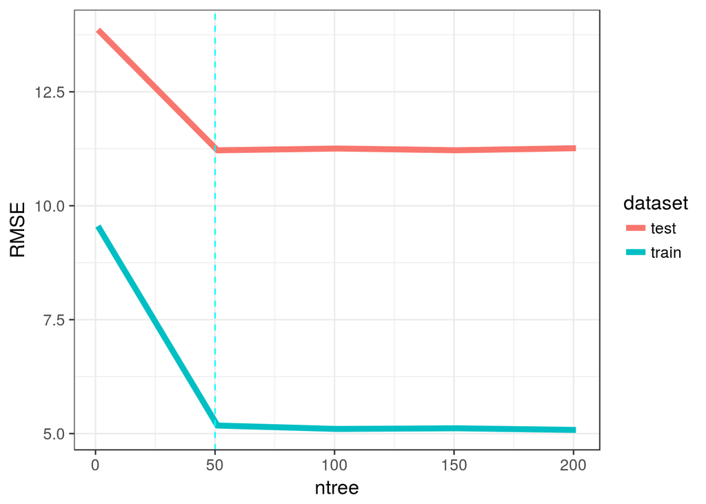

```r
n <- seq(1, 250, 50)
testing_ntree <- sapply(n, function(x) wrapper(train, test,
                    runs.number=50, ntree=x))

testing_ntree <- data.frame(n, t(testing_ntree))

to_plot <- data.frame(ntree = c(n, n),
                      RMSE=c(testing_ntree$RMSE_train, testing_ntree$RMSE_test),
                      dataset=c(rep("train", 5), rep("test", 5)))


ggplot(to_plot, aes(x = ntree, y = RMSE, col=dataset)) +
  geom_line(size=2) +
  theme_bw(base_size = 14) +
  geom_vline(xintercept = 50, lty="dashed", color="cyan")
```

```r
# ntree = 100
```

**2) sampsize and replace**

Здесь мы подбираем, какого размера надо взять выборку для построения отдельного дерева (sampsize), и можем ли мы брать с заменой или нет (replace). Оказалось, что размер выборки для дерева важен, потому что если брать слишком большую выборку, да еще и не разрешать замены, то происходит переобучение, и размер ошибки на тестовой выборке опять ползет вверх! Поэтому мы подобрали оптимальное значение sampsize в промежутке от 11 до 20, выбрав 16, и разлешили replace.

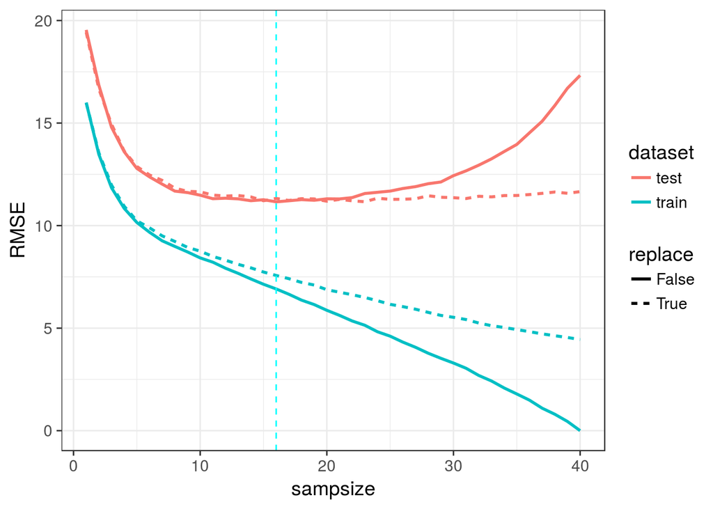

```r
sam <- seq(1, 40)

testing_replace_T <- sapply(sam, function(x) wrapper(train, test,
                    runs.number=50, ntree=100, mtry=10, nodesize = 1, replace = T, sampsize = x))

testing_replace_F <- sapply(sam, function(x) wrapper(train, test,
                    runs.number=50, ntree=100, mtry=10, nodesize = 1, replace = F, sampsize = x))

testing_sampsize_T <- data.frame(n, t(testing_replace_T))
testing_sampsize_F <- data.frame(n, t(testing_replace_F))

to_plot <- NULL
to_plot <- data.frame(
  sampsize=c(sam, sam, sam, sam), RMSE=c(testing_sampsize_T$RMSE_train, testing_sampsize_T$RMSE_test, testing_sampsize_F$RMSE_train, testing_sampsize_F$RMSE_test),
  dataset=c(rep("train", length(sam)), rep("test", length(sam)), rep("train", length(sam)), rep("test", length(sam))),
  replace=c(rep("True", 2*length(sam)), rep("False", 2*length(sam))))


ggplot(to_plot, aes(x = sampsize, y = RMSE, col=dataset, linetype=replace)) +
  geom_line(size=1) +
  theme_bw(base_size = 14) +
  geom_vline(xintercept = 16, lty="dashed", color="cyan")
```

```r
# sampsize = 16, replace = True
```

**3) nodesize**

Здесь мы задаем минимальный размер конечной ноды, чтобы не происходило переобучения и создания нод размером в один образец. На графике видно, что с ростом размера финальной ноды возрастает и ошибка, причем на значении 15 происходит резкий скачек в обучении, и только на nodesize = 1 ошибка тестовой выборки начинает расти.

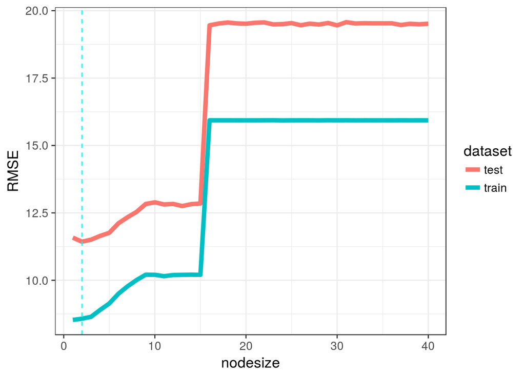

```r
n <- seq(1, 40)
testing_nodesize <- sapply(n, function(x) wrapper(train, test,
                    runs.number=50, ntree=100, sampsize = 11, replace = T, mtry=10, nodesize=x))

testing_nodesize <- data.frame(n, t(testing_nodesize))

to_plot <- NULL
to_plot <- data.frame(nodesize=c(n, n), RMSE=c(testing_nodesize$RMSE_train, testing_nodesize$RMSE_test), dataset=c(rep("train", max(n)), rep("test", max(n))))


ggplot(to_plot, aes(x = nodesize, y = RMSE, col=dataset)) +
  geom_line(size=2) +
  theme_bw(base_size = 14)+
  geom_vline(xintercept = 2, lty="dashed", color="cyan")
```

```r
# nodesize 2
```

**4) mtry**

Этот параметр определяет количество переменных, которые рандомно отбираются как кандидаты на разделение ветвей.

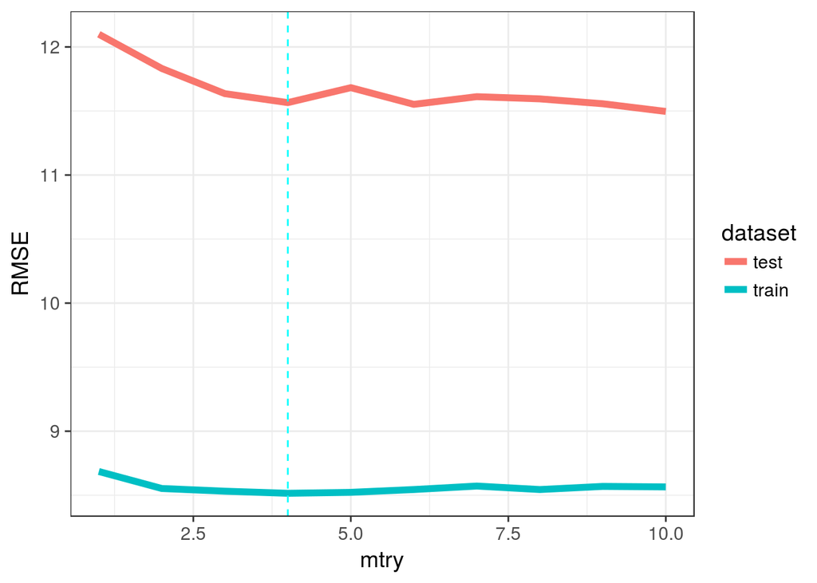

```r
n <- seq(1, 10)
testing_mtry <- sapply(n, function(x) wrapper(train, test,
                    runs.number=50, ntree=100, sampsize = 11, replace = T, mtry=x, nodesize=2))

testing_mtry <- data.frame(n, t(testing_mtry))

to_plot <- NULL
to_plot <- data.frame(mtry=c(n, n), RMSE=c(testing_mtry$RMSE_train, testing_mtry$RMSE_test), dataset=c(rep("train", max(n)), rep("test", max(n))))


ggplot(to_plot, aes(x = mtry, y = RMSE, col=dataset)) +
  geom_line(size=2) +
  theme_bw(base_size = 14)+
  geom_vline(xintercept = 4, lty="dashed", color="cyan")
```

```r
# mtry = 4
```

## Кросс-валидация

И вот, когда мы подобрали все параметры, надо проверить, всё ли действительно так, как кажется. И мы проводим кросс-валидацию, разбивая изначальные данные на пять выборок.

```r
set.seed(31)

# splitting our dataset into 5 equal parts
cross.validation <- matrix(sample(1:50, 50), nrow=5, ncol=10)
cross.validation
```

```
##      [,1] [,2] [,3] [,4] [,5] [,6] [,7] [,8] [,9] [,10]
## [1,]   27   48   14    5   35    2   22   29   46    28
## [2,]   47   37   33    4   17   31   50   32    7    42
## [3,]   21    8   25   16   11   19    9    3   49    41
## [4,]   20   40    1   43   13   24   12   39   36     6
## [5,]   44   10   30   34   15   38   23   26   18    45
```

```r
meth_for_cross <- cbind(meth[,idx], age=meth[,96])
```

И считаем, что получилось:

```r
crvalid <- function(cross.validation, meth_for_cross, runs.number=100, ...){
  cross.results <- apply(cross.validation, 1, function(test.sample){
  # using each part as testing dataset
  train.sample <- (1:50)[-test.sample]
  train <- meth_for_cross[train.sample, ]

  # using rest of the dataset as training dataset
  test <- meth_for_cross[test.sample, ]

  # calculating RMSE for every part and default random forest
  return(wrapper(train, test, runs.number, ...))
})
  return(rowMeans(cross.results))
}
```

## Результаты кросс-валидации

```r
# Default
print(crvalid(cross.validation, meth_for_cross))
```

```
## RMSE_train  RMSE_test
##   4.867972  11.253267
```

```r
# Set
print(crvalid(cross.validation, meth_for_cross, ntree=100, sampsize = 16, replace = T, mtry=4, nodesize=2))
```

```
## RMSE_train  RMSE_test
##    7.34199   10.98484
```